# Clase 4: Visualización de datos en R

Introducción a la Programación para Economistas

2026-07-02

```r
library(tidyverse)
library(patchwork)
```

# Los datos: DENUE

Dentro de esta plataforma, utilizaré la consulta de Servicios de alojamiento temporal, el cual incluye Hoteles, moteles y similares, Campamentos y albergues recreativos, así como Pensiones y casas de huéspedes, y departamentos de renta. Se plantea la pregunta: Cómo se distribuyen los establecimientos de alojamiento temporal entre los municipios de los estados con mayor oferta turística en México.

```r
datos <- read_csv('alojamiento.csv',
                      locale = locale(encoding = "latin1"))
glimpse(datos)
```

```
## Rows: 28,298
## Columns: 42
## $ ID                                                        <dbl> 6281529, 625…
## $ Clee                                                      <chr> "01001721112…
## $ `Nombre de la Unidad Económica`                           <chr> "1AGCI ONE A…
## $ `Razón social`                                            <chr> "FIDEICOMISO…
## $ `Código de la clase de actividad SCIAN`                   <dbl> 721111, 7211…
## $ `Nombre de clase de la actividad`                         <chr> "Hoteles con…
## $ `Descripcion estrato personal ocupado`                    <chr> "11 a 30 per…
## $ `Tipo de vialidad`                                        <chr> "BOULEVARD",…
## $ `Nombre de la vialidad`                                   <chr> "JOSE MARIA …
## $ `Tipo de entre vialidad 1`                                <chr> "CALLE", "AV…
## $ `Nombre de entre vialidad 1`                              <chr> "JESÚS MARÍA…
## $ `Tipo de entre vialidad 2`                                <chr> "CALLE", "CA…
## $ `Nombre de entre vialidad 2`                              <chr> "ROBERTO DÍA…
```

[output cut: 29 more lines]

# Reconocimiento de lenguaje

```r
library(readr)
guess_encoding('alojamiento.csv')
```

```
## # A tibble: 2 × 2
##   encoding   confidence
##   <chr>           <dbl>
## 1 ISO-8859-1       0.57
## 2 ISO-8859-2       0.35
```

# Limpieza rápida

Seleccionamos solo las columnas útiles y les damos nombres manejables:

```r
aloj_temp <- datos %>%
  select(
    id          = ID,
    actividad   = `Nombre de clase de la actividad`,
    estrato     = `Descripcion estrato personal ocupado`,
    municipio   = Municipio,
    entidad     = `Entidad federativa`,
    tipo        = `Tipo de asentamiento humano`,
    lat         = Latitud,
    lon         = Longitud,
    scian   = `Código de la clase de actividad SCIAN`,
    fecha_inc  = `Fecha de incorporación al DENUE`
  ) %>%
  mutate(
    año_inc = str_sub(fecha_inc, 1, 4) %>% as.integer(),
    estrato = fct_relevel(estrato,
      "0 a 5 personas", "6 a 10 personas", "11 a 30 personas",
      "31 a 50 personas", "51 a 100 personas", "101 a 250 personas"))
aloj_temp
```

```
## # A tibble: 28,298 × 11
##        id actividad estrato municipio entidad tipo    lat   lon  scian fecha_inc
##     <dbl> <chr>     <fct>   <chr>     <chr>   <chr> <dbl> <dbl>  <dbl> <chr>
##  1 6.28e6 Hoteles … 11 a 3… Aguascal… AGUASC… CIUD…  21.8 -102. 721111 2010-07
##  2 6.25e6 Hoteles … 51 a 1… Aguascal… AGUASC… COLO…  21.9 -102. 721111 2010-07
##  3 9.81e6 Hoteles … 0 a 5 … Aguascal… AGUASC… COLO…  21.9 -102. 721112 2024-11
##  4 9.60e6 Departam… 0 a 5 … Aguascal… AGUASC… FRAC…  21.9 -102. 721312 2024-11
##  5 9.77e6 Departam… 0 a 5 … Aguascal… AGUASC… COLO…  21.9 -102. 721312 2024-11
##  6 6.28e6 Hoteles … 11 a 3… Aguascal… AGUASC… COLO…  21.9 -102. 721112 2010-07
##  7 1.08e7 Hoteles … 0 a 5 … Aguascal… AGUASC… COLO…  21.9 -102. 721112 2024-11
##  8 8.54e6 Moteles   11 a 3… Aguascal… AGUASC… UNID…  21.9 -102. 721113 2019-11
##  9 1.12e7 Moteles   31 a 5… Aguascal… AGUASC… FRAC…  21.9 -102. 721113 2024-11
## 10 9.98e6 Cabañas,… 0 a 5 … Calvillo  AGUASC… COLO…  21.8 -103. 721190 2024-11
## # ℹ 28,288 more rows
## # ℹ 1 more variable: año_inc <int>
```

# Verificación de variables NA

```r
summary(aloj_temp)
```

```
##        id            actividad                       estrato
##  Min.   :     288   Length:28298       0 a 5 personas    :15311
##  1st Qu.: 6271644   Class :character   6 a 10 personas   : 5649
##  Median : 6384174   Mode  :character   11 a 30 personas  : 5117
##  Mean   : 7381495                      31 a 50 personas  :  891
##  3rd Qu.: 9284323                      51 a 100 personas :  661
##  Max.   :12289239                      101 a 250 personas:  368
##                                        251 y más personas:  301
##   municipio           entidad              tipo                lat
##  Length:28298       Length:28298       Length:28298       Min.   :14.59
##  Class :character   Class :character   Class :character   1st Qu.:18.74
##  Mode  :character   Mode  :character   Mode  :character   Median :19.94
##                                                           Mean   :20.69
##                                                           3rd Qu.:21.24
##                                                           Max.   :32.72
##
##       lon              scian         fecha_inc            año_inc
##  Min.   :-117.12   Min.   :721111   Length:28298       Min.   :2010
##  1st Qu.:-102.33   1st Qu.:721111   Class :character   1st Qu.:2010
##  Median : -99.16   Median :721112   Mode  :character   Median :2014
##  Mean   : -99.40   Mean   :721142                      Mean   :2016
##  3rd Qu.: -96.73   3rd Qu.:721113                      3rd Qu.:2020
##  Max.   : -86.72   Max.   :721312                      Max.   :2026
##
```

```r
colSums(is.na(aloj_temp))
```

```
##        id actividad   estrato municipio   entidad      tipo       lat       lon
##         0         0         0         0         0         2         0         0
##     scian fecha_inc   año_inc
##         0         0         0
```

# Gráficos iniciales

Se presentará cuál es la distribución de establecimientos de alojamiento temporales en las 5 entidades federativas con mayor oferta turística en México.

```r
top5_estados <- aloj_temp %>%
  count(entidad, sort = TRUE) %>%
  slice_head(n = 5)

top5_estados
```

```
## # A tibble: 5 × 2
##   entidad                             n
##   <chr>                           <int>
## 1 OAXACA                           2113
## 2 VERACRUZ DE IGNACIO DE LA LLAVE  2104
## 3 JALISCO                          1906
## 4 CHIAPAS                          1758
## 5 PUEBLA                           1624
```

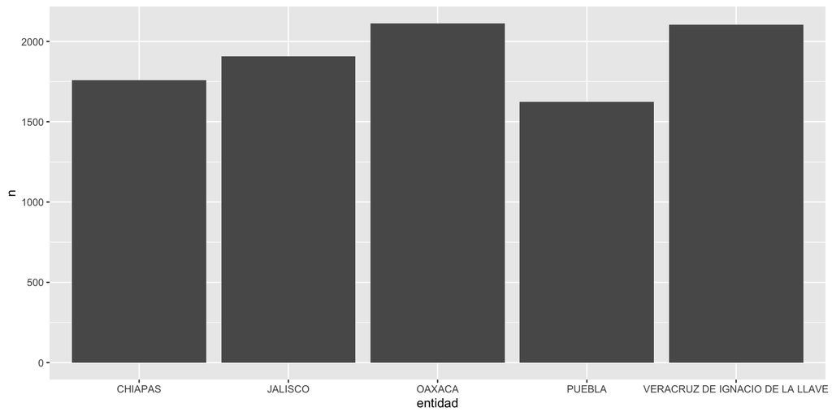

```r
ggplot(data    = top5_estados,
       mapping = aes(x = entidad,
                     y = n)) +
  geom_col()
```

# Distribución de establecimientos por entidad federativa

```r
municipios_top5 <- aloj_temp %>%
  filter(entidad %in% top5_estados$entidad) %>%
  count(entidad, municipio, sort = TRUE)

municipios_top5
```

```
## # A tibble: 730 × 3
##    entidad                         municipio                      n
##    <chr>                           <chr>                      <int>
##  1 OAXACA                          Oaxaca de Juárez             438
##  2 JALISCO                         Guadalajara                  359
##  3 PUEBLA                          Puebla                       342
##  4 CHIAPAS                         San Cristóbal de las Casas   340
##  5 VERACRUZ DE IGNACIO DE LA LLAVE Tecolutla                    248
##  6 JALISCO                         Puerto Vallarta              210
##  7 CHIAPAS                         Tuxtla Gutiérrez             201
##  8 VERACRUZ DE IGNACIO DE LA LLAVE Veracruz                     200
##  9 OAXACA                          Santa María Huatulco         194
## 10 CHIAPAS                         Tapachula                    174
## # ℹ 720 more rows
```

# Concentración de alojamientos temporales por entidad federativa (porcentaje)

```r
municipios_top5 <- municipios_top5 %>%
  group_by(entidad) %>%
  mutate(
    porcentaje = n / sum(n) * 100
  ) %>%
  ungroup()
municipios_top5
```

```
## # A tibble: 730 × 4
##    entidad                         municipio                      n porcentaje
##    <chr>                           <chr>                      <int>      <dbl>
##  1 OAXACA                          Oaxaca de Juárez             438      20.7
##  2 JALISCO                         Guadalajara                  359      18.8
##  3 PUEBLA                          Puebla                       342      21.1
##  4 CHIAPAS                         San Cristóbal de las Casas   340      19.3
##  5 VERACRUZ DE IGNACIO DE LA LLAVE Tecolutla                    248      11.8
##  6 JALISCO                         Puerto Vallarta              210      11.0
##  7 CHIAPAS                         Tuxtla Gutiérrez             201      11.4
##  8 VERACRUZ DE IGNACIO DE LA LLAVE Veracruz                     200       9.51
##  9 OAXACA                          Santa María Huatulco         194       9.18
## 10 CHIAPAS                         Tapachula                    174       9.90
## # ℹ 720 more rows
```

# Gráfica

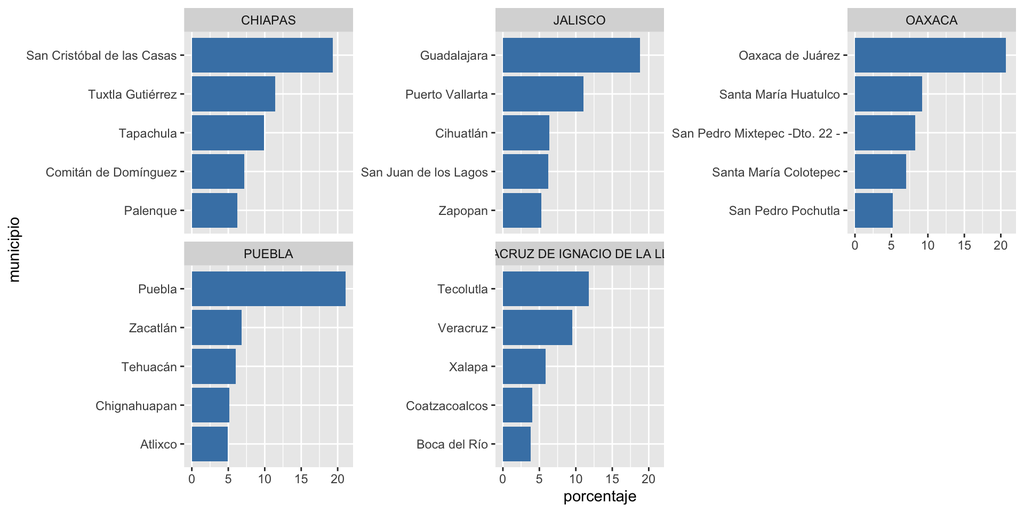

```r
municipios_top5 %>%
  group_by(entidad) %>%
  slice_max(n,                       #valores maximos de cada variable
            n = 5,
            with_ties = FALSE) %>%    #Si hay empate en el quinto lugar, conservarlos
  ungroup() %>%
  mutate(municipio = fct_reorder(municipio,
                            porcentaje)
  ) %>%
  ggplot(aes(x = porcentaje,
             y = municipio))+
    geom_col(fill="steelblue")+
    facet_wrap(~entidad,
               scales="free_y")
```

# Diseño de gráfico

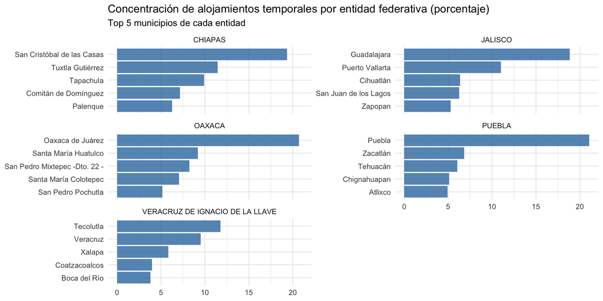

```r
municipios_top5 %>%
  group_by(entidad) %>%
  slice_max(n,                       #valores maximos de cada variable
            n = 5,
            with_ties = FALSE) %>%    #Si hay empate en el quinto lugar, conservarlos
  ungroup() %>%
  mutate(municipio = fct_reorder(municipio,
                            porcentaje)
  ) %>%
  ggplot(aes(x = porcentaje,y = municipio))+
    geom_col(fill="steelblue", alpha = 0.85)+
    facet_wrap(~entidad,scales="free_y", ncol = 2)+
  labs(title = "Concentración de alojamientos temporales por entidad federativa (porcentaje)",
       subtitle = "Top 5 municipios de cada entidad",
       x = NULL , y = NULL) +
  theme_minimal()
```

# Interpretación

Estas gráficas nos muestran que la oferta de establecimientos de alojamiento temporal se encuentra concentrada en algunos municipios dentro de cada una de las cinco top entidades analizadas. Sin embargo, el grado de concentración varía entre estados. En Puebla, el municipio de Puebla concentra aproximadamente el 21% de los establecimientos de alojamiento del estado, en Veracruz, la distribución es más equilibrada, ya que el municipio de Tecolutla representa cerca del 12% del total estatal.